# Введение

### Проанализируем окупаемость рекламы с разбивкой по рекламным каналам

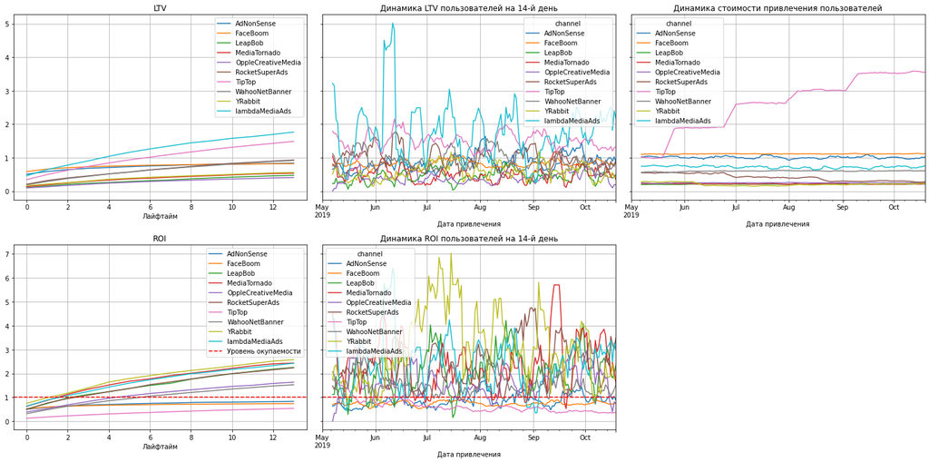

```python
# Проанализируем окупаемость рекламы с разбивкой по рекламным каналам.
# Построим графики LTV и ROI, а также графики динамики LTV, CAC и ROI

result_raw, ltv, ltv_history, roi, roi_history = get_ltv(
    non_organic_profiles,
    orders,
    observation_date,
    horizon_days,
    dimensions=['channel'],
    ignore_horizon=False,
)

plot_ltv_roi(ltv, ltv_history, roi, roi_history, horizon_days)
```

По графикам видно, что реклама не окупается не везде. Начиная с июня начала расти стоимость привлечения клиентов только по каналу TipTop — CAC по остальным каналам практически не изменился. Лучше всего окупается канал YRabbit, хорошие результаты можно выделить у канала MediaTornado, а совсем не окупаются каналы, в которых самая дорогая средняя стоимость клиента — TipTop, FaceBoom и AdNonSense. Ещё один интересный вывод: пользователи, привлечённые каналом lambdaMediaAds демонстрируют наибольшие значения «пожизненной ценности» — это хорошо видно на графике динамики LTV.

### Проанализируем окупаемость рекламы с разбивкой по устройствам

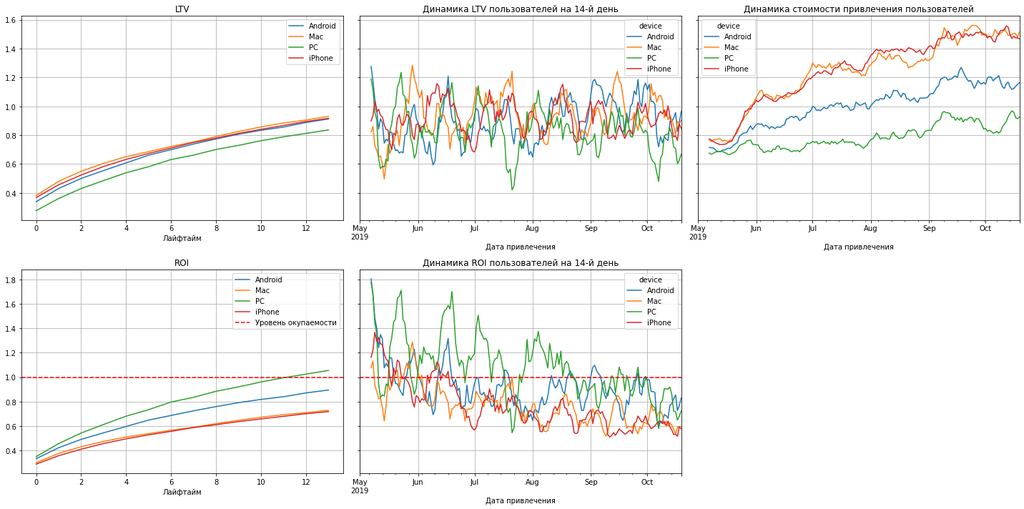

```python
# Проанализируем окупаемость рекламы с разбивкой по устройствам.
# Построим графики LTV и ROI, а также графики динамики LTV, CAC и ROI

result_raw, ltv, ltv_history, roi, roi_history = get_ltv(
    non_organic_profiles,
    orders,
    observation_date,
    horizon_days,
    dimensions=['device'],
    ignore_horizon=False,
)

plot_ltv_roi(ltv, ltv_history, roi, roi_history, horizon_days)
```

По графикам видно, что, начиная с июня 2019-го года средняя стоимость привлечения больше всего выросла для владельцев айфонов и мак. Меньше всего она выросла для владельцев PC. У них стабильно самый низкий уровень LTV, но он выше уровня CAC. Вероятно, по этой причине владельцы PC демонстрируют показатели ROI выше уровня окупаемости на 14-й день.

### Проанализируем окупаемость рекламы с разбивкой по странам

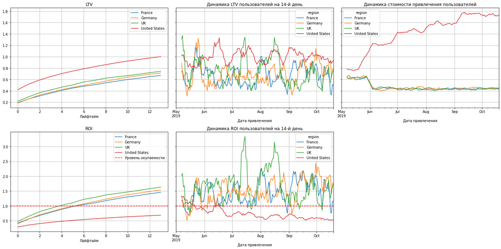

```python
# Проанализируем окупаемость рекламы с разбивкой по странам.
# Построим графики LTV и ROI, а также графики динамики LTV, CAC и ROI

result_raw, ltv, ltv_history, roi, roi_history = get_ltv(
    non_organic_profiles,
    orders,
    observation_date,
    horizon_days,
    dimensions=['region'],
    ignore_horizon=False,
)

plot_ltv_roi(ltv, ltv_history, roi, roi_history, horizon_days)
```

Клиенты из США отличаются самыми высокими показателями «пожизненной ценности». Однако, с июня месяца стоимость привлечения таких клиентов резко выросла и они перестали окупать себя: на графике динамики ROI пользователей на 14-й день мы можем видеть, что примерно со второй половины июня значения, которые соответствуют пользователям из США не оказывались выше линии уровня окупаемости. Стоимость привлечения клиентов из других стран с июня 2019-го стала дешевле. По графику видно, что эти клиенты стабильно окупаются

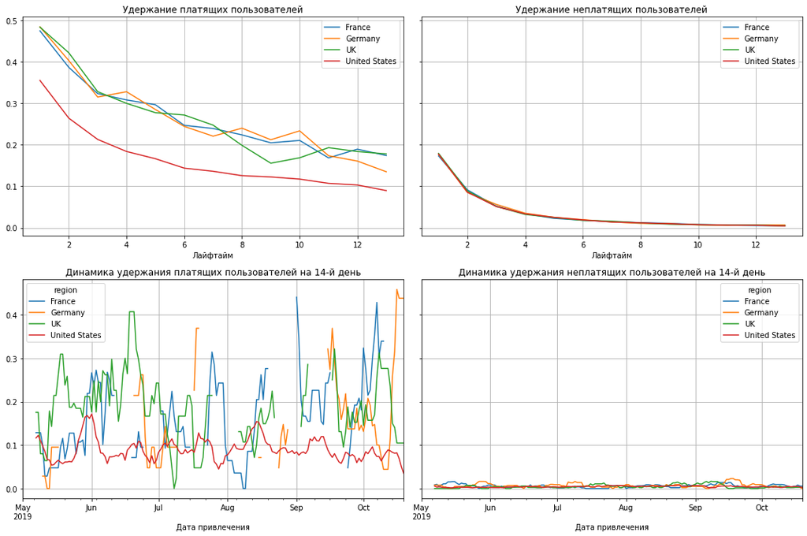

```python
# Рассмотрим удержание пользователей по странам

retention_raw, retention, retention_history = get_retention(
    non_organic_profiles, visits, observation_date, horizon_days, dimensions=['region']
)

plot_retention(retention, retention_history, horizon_days)
```

Удержание неплатящих пользователей из разных стран на графике убывает по экспоненте и находится примерно на одном уровне. Среди платящих пользователей наименьший показатель у США: удержание 14-го дня находится в районе 10%. Лучше дела у платящих пользователей из Франции и Великобритании — на 14-й день показатель чуть ниже 20%.

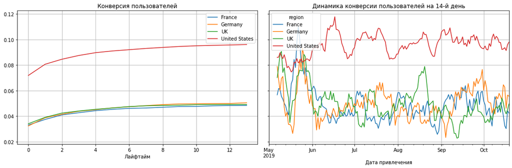

```python
# Рассмотрим конверсию пользователей по странам

conversion_raw, conversion, conversion_history = get_conversion(
    non_organic_profiles, orders, observation_date, horizon_days, dimensions=['region']
)

plot_conversion(conversion, conversion_history, horizon_days)
```

Мы говорили о том, что удержание платящих пользователей из США ниже, чем у платящих пользователей из других стран. На графиках конверсии видно, что конверсия пользователей из США выше остальных. Пользователи из США лучше конвертируются, но хуже удерживаются. Можно предположить, что причина в какой-то технической проблеме, возникающей у клиентов из США. Повод для нового исследования.

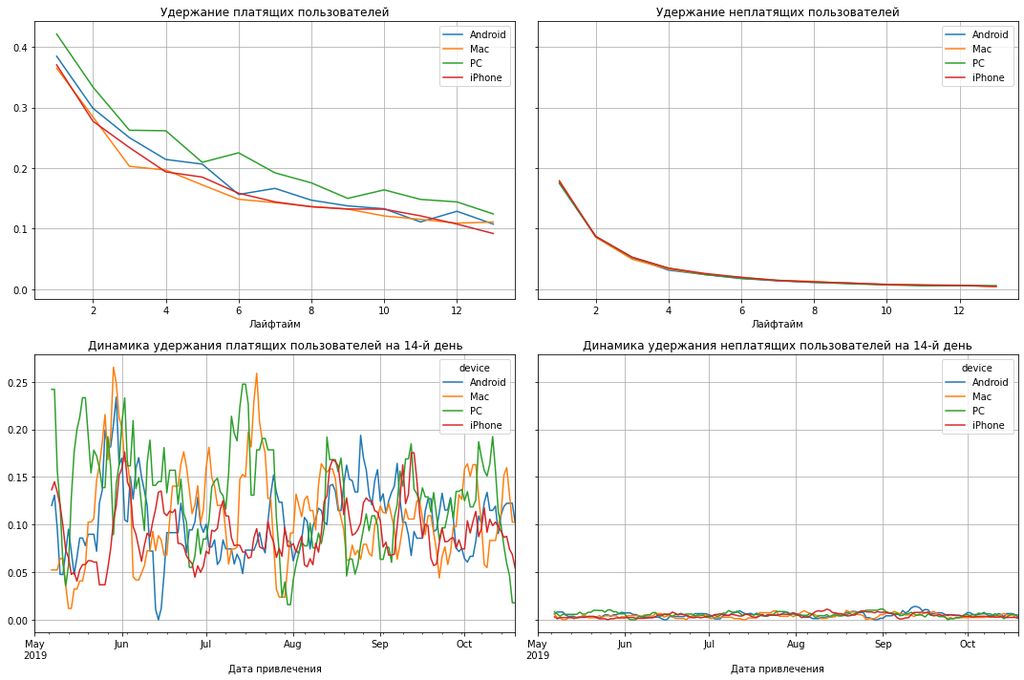

```python
# Рассмотрим удержание пользователей по устройствам

retention_raw, retention, retention_history = get_retention(
    non_organic_profiles, visits, observation_date, horizon_days, dimensions=['device']
)

plot_retention(retention, retention_history, horizon_days)
```

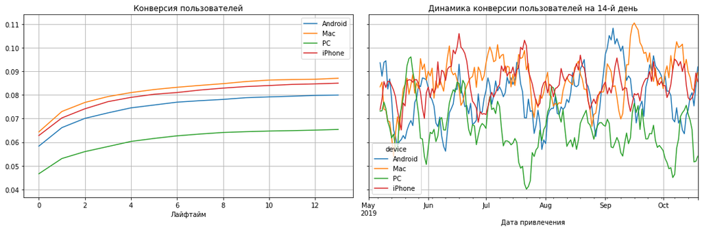

```python
# Рассмотрим конверсию пользователей по устройствам

conversion_raw, conversion, conversion_history = get_conversion(
    non_organic_profiles, orders, observation_date, horizon_days, dimensions=['device']
)

plot_conversion(conversion, conversion_history, horizon_days)
```

А вот конвертируются пользовали PC хуже остальных. Это наводит на мысли о необходимости улучшения версии приложения или сайта для компьютеров.

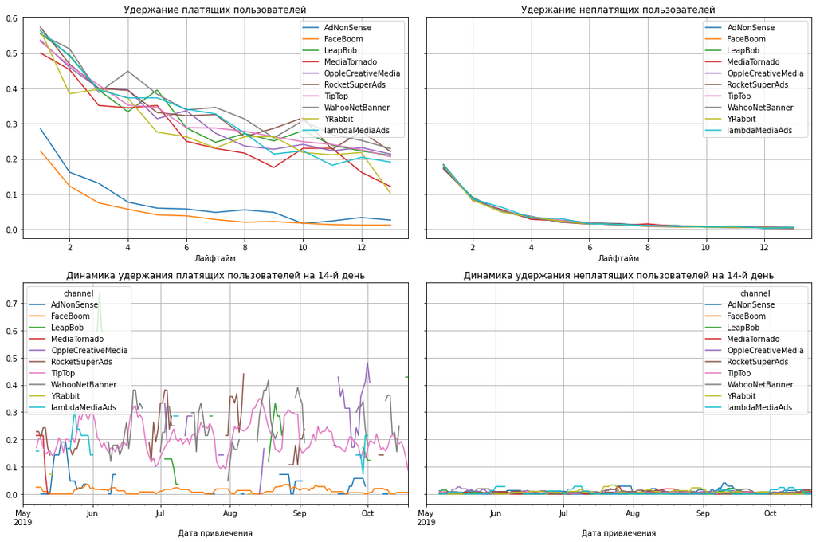

```python
# Рассмотрим удержание пользователей по каналам

retention_raw, retention, retention_history = get_retention(
    non_organic_profiles, visits, observation_date, horizon_days, dimensions=['channel']
)

plot_retention(retention, retention_history, horizon_days)
```

Ситуация с неплатящими пользователями аналогична рассмотренным ранее — выделить лидеров и аутсайдеров тяжело: показатели разных каналов находятся на одном уровне. Среди платящих пользователей худшее удержание демонстрируют каналы FaceBoom и AdNonSense — 1-2% на 14-й день. Эти каналы мы отмечали, как одни из самых дорогих. Повод задуматься о пересмотре условий сотрудничества или даже об отказе от использования этих каналов привлечения.

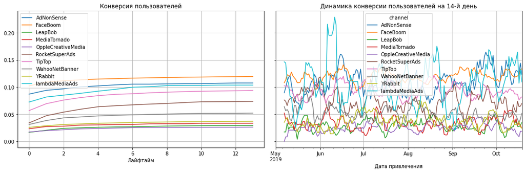

```python
# Рассмотрим конверсию пользователей по каналам

conversion_raw, conversion, conversion_history = get_conversion(
    non_organic_profiles, orders, observation_date, horizon_days, dimensions=['channel']
)

plot_conversion(conversion, conversion_history, horizon_days)
```

# Шаг 6. Напишем выводы

- Выделим причины неэффективности привлечения пользователей;
- Сформируем рекомендации для отдела маркетинга для повышения эффективности.

В качестве рекомендаций для отдела маркетинга можно было бы вынести предложение категоричного отказа от дальнейшего сотрудничества с каналами привлечения FaceBoom и AdNonSense. Обязательно имеет смысл изучить возможные технические проблемы, которые возникают у клиентов из США и поработать над ними. Если окажется, что дело не в них, то можно пойти на радикальные меры и рассмотреть уход с рынка США в качестве следующего шага, если после отказа от каналов FaceBoom и AdNonSense ситуация не стабилизируется. Стоит поработать над интерфейсом развлекательного приложения для PC — возможно, если пересмотреть его, то показатели LTV и конверсии у владельцев этого типа устройств вырастут.